# Humanitarian Funding Flows Analysis

Donor Profile: Germany, Government of

Author

AI Generated Analysis based on [OCHA Finantial Tracking Service Data API](https://fts.unocha.org/). Beware of data limitations and potential hallucinations! Thanks for reporting any [issues here](https://github.com/Edouard-Legoupil/ftsAnalysis/issues/new) – View all Reports

## Executive Summary

The Government of Germany emerges as a major and dynamic humanitarian donor with a substantial funding portfolio marked by significant volatility and strategic focus. Between 2020 and 2025, Germany drastically scaled up its humanitarian contributions, culminating in a peak nearing 655 million USD, reflecting responsive adjustments to escalating global crises. However, a sharp projected decline post-2025 signals potential unpredictability, emphasizing the need for adaptive planning and reinforced partnerships among implementing actors to mitigate funding fluctuations and ensure program continuity.

A pronounced imbalance characterizes Germany’s contribution types, with the vast majority of funds funneled through a single dominant delivery channel. This concentration may heighten program effectiveness in specific areas but risks limiting innovation and the scope of interventions. Diversifying funding flows would be strategic to broaden assistance mechanisms and better address multifaceted humanitarian needs.

Sectorally, Germany’s funding strongly prioritizes key clusters—likely health, food security, and protection—evidenced by high volumes of funding flows. This reflects alignment with pressing global needs and strategic focus areas. Nonetheless, lesser-supported sectors indicate opportunities for advocates to promote a more balanced distribution, ensuring comprehensive crisis response coverage.

In summary, Germany stands as a pivotal donor offering significant but variable funding with targeted earmarking and concentrated delivery flows. Humanitarian stakeholders engaging with Germany should emphasize building flexible funding arrangements, promoting diversified channels, and aligning proposals with prioritized sectors to maximize collaborative impact and contribute to resilient, effective humanitarian response.

## Funding History

Between 2020 and 2026, Germanys government funding for humanitarian efforts has experienced dramatic fluctuations, indicating shifting priorities and responses to emerging global crises. Starting from a modest 865,000 USD in 2020, funding saw a significant rise to over 53 million USD in 2022, and then surged sharply to nearly 655 million USD in 2025. This steep increase suggests an urgent scaling of support, likely in response to intensified humanitarian needs worldwide, such as conflicts, natural disasters, or pandemic repercussions. However, the sudden drop to 900,000 USD projected for 2026 raises concerns about the sustainability or predictability of funding levels, which could undermine ongoing humanitarian programs. For executives, this pattern signals the importance of preparing for considerable variability in donor contributions. The peak funding years represent opportunities to accelerate impact, but the volatility also underscores the need for flexible planning and strengthened partnerships to mitigate potential shortfalls. To optimize humanitarian response, stakeholders should advocate for more consistent funding commitments from key donors like Germany, ensuring steady support for vulnerable populations and allowing effective long-term program implementation.

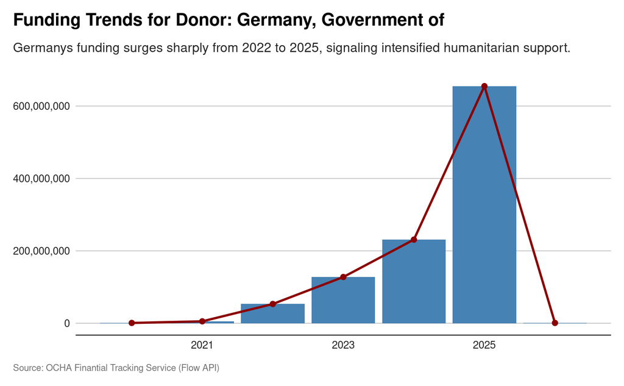

## Earmaking Approach

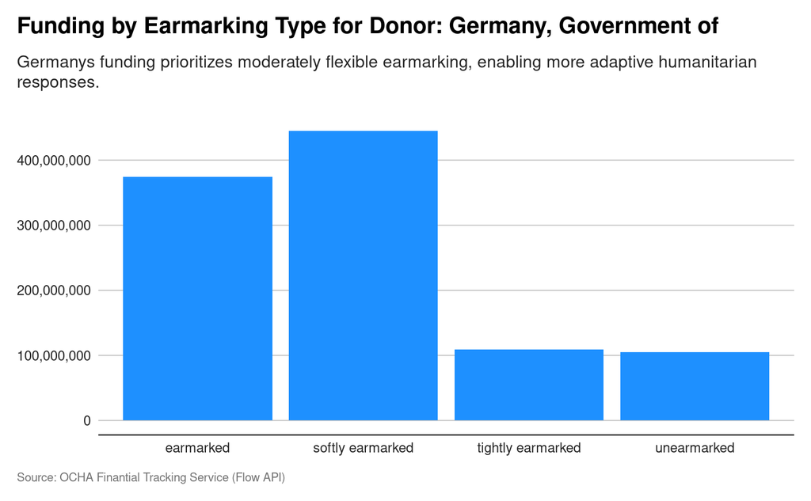

## Contribution Type

The funding flow analysis for the Germany Government reveals a stark contrast in the distribution of humanitarian assistance by flow type. The data shows that the vast majority of funding, over 1 billion USD, is channeled through the second flow type category, while a much smaller amount, approximately 435,000 USD, is allocated to the first flow type. This significant imbalance highlights a concentrated approach where one mode of assistance delivery dominates the funding landscape. For humanitarian leaders and decision-makers, this pattern suggests the need to scrutinize the effectiveness and reach of the predominant flow type. While concentrated funding can boost impact in targeted areas, it may also risk overlooking diverse needs or innovative mechanisms that the smaller flow type might support. The relatively minor allocation to the first category indicates potential underutilization of alternative or complementary intervention pathways. In response, a strategic review of the flow type distribution could enhance the flexibility and responsiveness of aid, ensuring a balanced portfolio that addresses emergent crises across different contexts. This insight calls for deliberate efforts to diversify funding streams, thereby strengthening humanitarian outcomes and resilience.

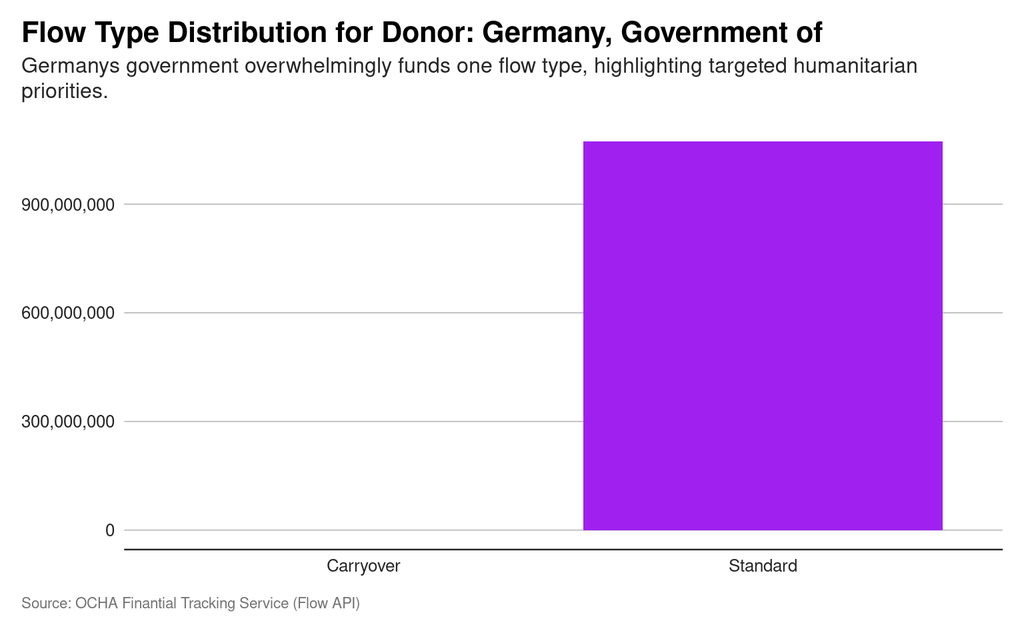

## Sectoral Prioritisation

The data reveals the Government of Germany’s humanitarian funding distribution across various clusters globally, highlighting their strategic priorities. Notably, the largest number of funding flows support the cluster with 196 flows, followed closely by clusters with 142 and 135 flows, indicating a strong commitment to these sectors. These likely represent critical areas such as health, food security, or protection, where urgent and sustained intervention is essential. Smaller clusters receive significantly fewer flows, some with as few as three, suggesting either less emphasis or a more targeted, specialized approach in these areas. This disparity in funding flow frequency reflects Germanys prioritization, possibly driven by global needs assessments and the impact potential of each sector. For humanitarian response planning, understanding this allocation pattern assists stakeholders in coordinating efforts, identifying funding gaps, and aligning project proposals with donor focus areas. It also underscores the necessity to advocate for balanced support across all clusters to address comprehensive needs in crises. Moving forward, this data can inform strategic dialogue and resource mobilization to strengthen partnerships and optimize impact.

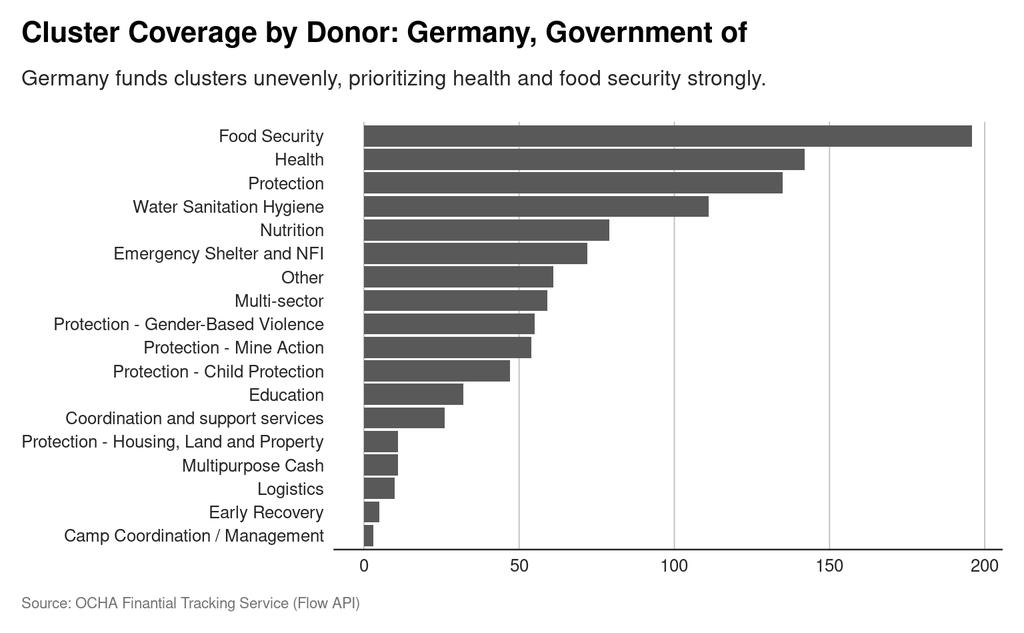